# Overview

Published

December 2, 2024

Modified

December 4, 2024

## Population structure

The proportion of the population by silo membership is shown in Table 1.

| Silo | Proportion |
| --- | --- |
| early | 0.3 |
| late | 0.5 |
| chronic | 0.2 |

Table 1: Population membership by silo

Each silo comprises patients with either a knee or hip infection. The assumed proportion of infections for each joint and for each silo are shown below.

| Silo | Joint | Proportion |
| --- | --- | --- |
| early | knee | 0.4 |
| early | hip | 0.6 |
| late | knee | 0.7 |
| late | hip | 0.3 |
| chronic | knee | 0.5 |
| chronic | hip | 0.5 |

Table 2: Population membership by silo and infection site

## Study structure

### Primary outcome

The primary outcome is treatment success at 12 months post platform entry, defined as **all of**:

1. Alive
2. Clinical cure (no clinical or microbiological evidence of infection)
3. No ongoing use of antibiotics for the index joint; and
4. The prosthesis present after the initial management strategy is complete (destination prosthesis) still in place

referred to as ‘treatment success’.

### Domains

#### Surgical

Early stage patients do not receive randomisation and are assumed to mostly receive DAIR, although they may have any form of surgery. We assume the proportion of dair, one and two-stage surgery to be 85%, 10% and 5%.

Late stage patients enter for randomised surgery and are allocated 1:1 to DAIR/revision. The clinician selects the specific type of revision (one-stage or two-stage) to be performed. For late stage infection patients that are randomised to dair, we assume that the preferences for dair, one and two-stage are 20%, 24% and 56%. For late stage infection patients that are randomised to revision, we assume that the preferences for one and two-stage are 30% and 70%.

Chronic stage patients do not receive randomisation and are assumed to receive DAIR, one-stage and two-stage based on clinician assessment. For chronic stage infection patients, we assume that the preferences for dair, one and two-stage are 20%, 20% and 60%.

#### Antibiotic backbone duration

Entry into antibiotic backbone duration domain is dependent on the surgery that was received. Specifically, this domain only applies for patients receiving one-stage revision.

Within the antibiotic backbone duration domain, allocation is to 12 weeks vs 6 weeks duration.

Patients receiving DAIR and two-stage revision are assumed to have 12 wk duration (not randomised).

#### Extended prophylaxis

Entry into extended prophylaxis domain is dependent on the surgery that was received. Specifically, this domain only applies for patients receiving two-stage revision.

Within the extended prophylaxis domain, allocation is to 12 weeks duration vs none following the second stage of the revision.

Patients receiving DAIR and one-stage revision are assumed to not receive any extended prophylaxis.

#### Antibiotic choice

Entry into antibiotic choice is primarily indicated by microbiology. For simplicity, the data generating process assumes that 60% of the total sample enter into this domain at random, unrelated to risk factors, irrespective of surgery type, silo and site of infection.

## Research questions

The questions of interest are as follows:

### Surgical

For the surgical domain we evaluate whether revision is superior to dair and futility for superiority. This applies only to the late silo cohort.

### Antibiotic backbone duration

For the backbone duration domain, we evaluate whether short duration (6 wk) is non-inferior to long duration (12 wk) antibiotic treatment. This is applicable only to participants that receive one-stage revision. We also evaluate whether the non-inferiority decision is futile in the sense that it appears unlikely that non-inferiority will ever be established.

### Extended prophylaxis

For ethe extended prophylaxis domain, we evaluate whether a 12 wk duration is superior to no extended prophylaxis. This is applicable only to participants that receive two-stage revision (the extended prophylaxis follows the second operation). We also evaluate whether the superiority decision is futile in the sense that it appears unlikely that superiority will ever be established.

### Antibiotic choice

For the choice domain we evaluate whether rifampicin is superior to no rifampicin. This is applicable to the participants that are enter into the choice domain. We also evaluate whether the superiority decision is futile in the sense that it appears unlikely that superiority will ever be established.

## Response rates

The baseline probability/log-odds of treatment success is assumed to vary by silo and site of infection as detailed below.

| Silo | Joint | Pr(trt success) | log-odds sucess |
| --- | --- | --- | --- |
| early | knee | 0.65 | 0.62 |
| early | hip | 0.75 | 1.10 |
| late | knee | 0.55 | 0.20 |
| late | hip | 0.60 | 0.41 |
| chronic | knee | 0.60 | 0.41 |
| chronic | hip | 0.65 | 0.62 |

Table 3: Baseline probability of treatment success by silo and site of infection

## Expected accrual

For the purposes of simulating the study cohort, accrual is assumed to follow a non-homogeneous Poisson process that ramps up over the first 12 months of enrolment and then has a steady state of around 1.5 per new entrants per day.

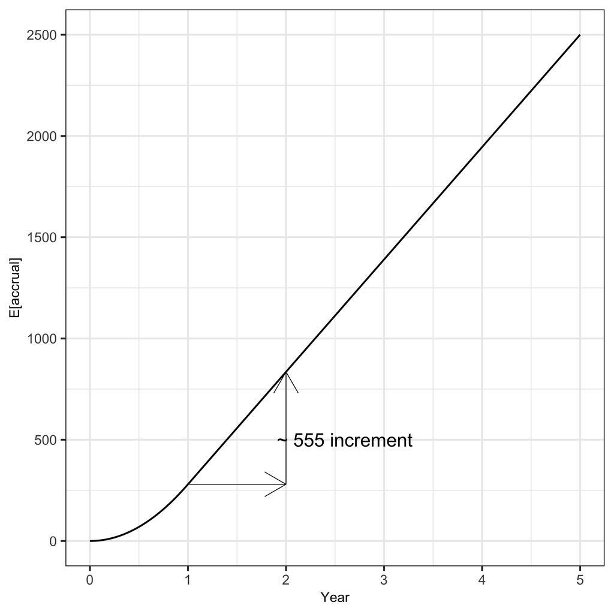

Figure 1: Expected accrual

```r
# events per day
lambda = 1.52
# ramp up over 12 months
rho = function(t) pmin(t/360, 1)

d_fig <- data.table(
  t = 0:(5 * 365),
  # expected number enrolled
  n = c(0, nhpp.mean(lambda, rho, t1 = 5 * 365, num.points = 5 * 365))
)

df1 <- data.table(x1 = 365/365,
                 x2 = 730/365,
                 y1 = d_fig[t == 365, n],
                 y2 = d_fig[t == 365, n]
                 )
df2 <- data.table(x1 = 730/365,
                 x2 = 730/365,
                 y1 = d_fig[t == 365, n],
                 y2 = d_fig[t == 730, n]
                 )

n_p_y <- d_fig[t == 730, n] - d_fig[t == 365, n]

ggplot(d_fig, aes(x = t/365, y = n)) +
  geom_line() +
  geom_segment(aes(x = x1,
                   y = y1,
                   xend = x2,
                   yend = y2),
               lty = 1, lwd = 0.2,
               arrow = arrow(length = unit(0.2, "inches")),
               data = df1) +
  geom_segment(aes(x = x1,
                   y = y1,
                   xend = x2,
                   yend = y2),
               lty = 1, lwd = 0.2,
               arrow = arrow(length = unit(0.2, "inches")),
               data = df2) +
  annotate("text",
           x = 2.6,
           y = 500,
           label = sprintf("~ %.0f increment", n_p_y)) +
  scale_x_continuous("Year") +
  scale_y_continuous("E[accrual]", breaks = seq(0, 2500, by = 500))
```

## Analyses

### Cohort data informing analyses

Different cohorts enter inform different parts of the experiment.

#### Early infection

Patients with early stage infection are not revealed to the surgical domain. The surgical intervention will usually be dair for which 12 weeks of backbone antibiotics are recommended. There are, however, instances where early stage infection patients will receive either one-stage or two-stage revision. These patients will be able to enter the randomised backbone duration domain (one-stage, but not two-stage) and the extended prophylaxis domain (two-stage, but not one-stage). Early silo patients will also enter the choice domain if they are eligible to do so.

#### Late infection

Patients with late infection can enter all domains with some restrictions. They are randomised to dair vs revision in the surgical domain. Patients allocated to revision will receive a one or two-stage procedure based on self-selection. Both the planned surgery (one-stage/two-stage) and the surgery actually performed should be captured – the former should be recorded at the time of randomisation. Patients receiving one-stage receive randomised backbone antibiotics. Patients receiving two-stage receive randomised extended prophylaxis. Late silo patients will also enter the choice domain if they are eligible to do so.

#### Chronic infection

Patients with chronic stage infection are not randomised into the surgical domain. Like the early silo cohort, they can enter into the antibiotic backbone domain and the extended prophylaxis domain based on the type of surgery they receive. Chronic silo patients will also enter the choice domain if they are eligible to do so.

### Missingness

Missingness is not currently implemented within the simulations.

### Non-differential follow-up

To avoid artifacts associated with non-differential follow-up (e.g. early vs late deaths), participants will be included in the analyses only when they reach the primary endpoints (12 months) irrespective of whether they experienced treatment failure before that time.

### Model specification

For each silo $l$ and site of infection $j$ we therefore simulate the probability of treatment success as:

$$\begin{aligned}
\text{logit}(\pi) &= \mu + \lambda_s + \rho_j + \phi_{l} + \sum_{d=1}^{D} x_d^\top \vec{\beta_d} + \zeta_{r,v} + \tau_t + z^\top \vec{\omega}
\end{aligned}
\tag{1}$$

- $\mu$ grand mean log-odds of treatment success; it serves as a reference from which all other effects deviate
- $\lambda_s$ change associated with membership silo $s$
- $\rho_j$ change associated with site of infection (joint) $j$
- $\phi_{l}$ preference for surgical approach under revision type $l$ with elements for non-randomised treatment, one-stage and two-stage
- $\vec{\beta_d}$ change associated treatment allocation with domain $d$
- $\zeta_{r,v}$ change associated with site $v$ nested within region $r$
- $\tau_t$ change associated with randomisation period $t$
- $\omega$ parameters associated with baseline factors

The trial data will be modelled as above with decisions made on the basis of the joint posterior, but an additional analysis model run with treatment by site of infection (hip/knee) interactions to characterise and report treatment heterogeneity.

## Decision rules

In the following, all treatment effect parameters relate back to the model specification provided earlier.

### Surgical domain

The surgical domain considers the effect of revision relative to dair in the late-stage infection silo.

Following the earlier model specification, let $\Delta_R = \beta_4 \mathbb{E}[\mathbb{I}(S_{R_P} == 1 \land R == 1)] + \beta_5 \mathbb{E}[\mathbb{I}(S_{R_P} == 2 \land R == 1)]$ correspond to the average conditional log-odds ratio associated with revision. The probability that revision is superior to dair is defined as:

$$\begin{aligned}
P_{\text{surgical (sup)}} = Pr(\Delta_R > 0)
\end{aligned}$$

and enrolment is stopped for superiority if $P_{\text{surgical (sup)}} > 0.99$.

The probability of futility for revision being superior to dair is defined as:

$$\begin{aligned}
P_{\text{surgical (fut)}} = Pr(\Delta_R > \log(1.2))
\end{aligned}$$

and enrolment is stopped for futility if $P_{\text{surgical (fut)}} < 0.05$.

### Duration domain

The duration domain considers the effect of short relative to long duration therapy depending on the type of revision received.

If, in the surgical domain, revision is found to be inferior to DAIR, then randomisation in the surgical domain will cease and DAIR will be recommended for all late acute who meet the domain eligibility criteria. But the duration domain will continue, because people in other silos will continue to have revision surgery (occasionally in Early and routinely in Chronic).

#### DAIR

No duration effects are applicable for DAIR.

#### One-stage revision

Let $\beta_6$ correspond to the conditional log-odds ratio associated with 6 weeks (short) duration antibiotics relative to 12 weeks (long) when one-stage revision is received. The probability that short is non-inferior to long is defined as:

$$\begin{aligned}
P_{\text{duration-1 (ni)}} = Pr(\beta_6 > \log(1/1.2))
\end{aligned}$$

and enrolment is stopped for non-inferiority if $P_{\text{duration-1 (ni)}} > 0.99$.

The probability of futility for revision being superior to dair is defined as:

$$\begin{aligned}
P_{\text{duration-1 (fut)}} = Pr(\beta_6 > \log(1))
\end{aligned}$$

and enrolment is stopped for futility (with respect to being able to establish non-inferiority) if $P_{\text{duration-1 (fut)}} < 0.05$.

#### Two-stage revision

$$\begin{aligned}
P_{\text{duration-2 (sup)}} = Pr(\beta_7 > 0)
\end{aligned}$$

and enrolment is stopped for superiority if $P_{\text{duration-2 (sup)}} > 0.99$.

The probability of futility for long duration being superior to short is defined as:

$$\begin{aligned}
P_{\text{duration-2 (fut)}} = Pr(\beta_7 > \log(1.2))
\end{aligned}$$

and enrolment is stopped for futility if $P_{\text{duration-2 (fut)}} < 0.05$.

### Choice domain

The choice domain considers the effect of rifampacin relative to no-rifampacin.

Let $\beta_{9}$ correspond to the conditional log-odds ratio associated with rifampacin relative to no-rifampacin The probability that rifampacin is superior to no-rifampacin is defined as:

$$\begin{aligned}
P_{\text{choice (sup)}} = Pr(\beta_{9} > 0)
\end{aligned}$$

and enrolment is stopped for superiority if $P_{\text{choice (sup)}} > 0.99$.

The probability of futility for rifampacin being superior to no-rifampacin is defined as:

$$\begin{aligned}
P_{\text{choice (fut)}} = Pr(\beta_{9} > \log(1.2))
\end{aligned}$$

and enrolment is stopped for futility if $P_{\text{choice (fut)}} < 0.05$.